# **Food Accessibility and Food Deserts in Select Cities**

## Rhegan Barrett & Kayla Willis

https://kayla200212.github.io/

# Collaboration Plan

We plan to meet once a week in person. We have a shared GitHub repository where we can upload datasets that will be used, as well as a shared Google Colab notebook where we can both analyze the datasets.

# Project Overview

For our project, we intend to look at datasets that provide data about grocery stores and income in different cities to analyze food inequality such as food deserts.

The datasets we used in this initial investigation were as follows:

https://catalog.data.gov/dataset/grocery-stores-2013/resource/4d1c5d3e-71f9-4a81-94ca-0bec6afa2b62

https://data.cityofchicago.org/Health-Human-Services/Per-Capita-Income/r6ad-wvtk

```python
import pandas as pd
import numpy as np
import matplotlib.pyplot as plt
%cd /content
!git clone https://github.com/kayla200212/Kayla200212.github.io
%cd /content/Kayla200212.github.io/Datasets
```

```
/content
fatal: destination path 'Kayla200212.github.io' already exists and is not an empty directory.
/content/Kayla200212.github.io/Datasets
```

# First Dataset: Grocery Stores in Chicago 2013

Our first data set is one that provides a list of all grocery stores in Chicago from 2013. This dataset comes from the City of Chicago’s business license data. Since this dataset is slightly outdated (one grocery store that appears in the dataset is Dominick’s, a store that went out of business), we would like to see if there is a way for us to filter or clean the business license data to get the most up to date list of grocery stores. We also noticed that some of the “grocery stores” included in the list are convenience stores such as Walgreens. While Walgreens does technically have groceries, it’s not a fully stocked grocery store so we decided to filter it out of the dataset. We would like to take a closer look at the stores included in this dataset in particular, as there might be other stores similar to Walgreens we would like to exclude. Choices such as these can help further guide our ETL steps as we gather and combine more datasets. The two most important variables in this data set are the name of the grocery store and the neighborhood the grocery store is in. One question we can ask using these metrics: which neighborhoods have the least amount of grocery stores? By using this as a starting point, we can use this to begin analysis of food inequality through comparison with other datasets.

```python
#read in our two datasets (so far)
chicago_2013 = pd.read_csv("../Datasets/Grocery_in_Chicago_2013.csv")
chic_per_cap = pd.read_csv("../Datasets/Chicago_Per_capita.csv")
#remove a handfull of columns which we do not need for this analysis for tidy purposes
chicago_2013 = chicago_2013.drop(chicago_2013.columns[[1, 3, 12, 13, 14, 15]], axis=1)
#set the index to the name, ok bc duplicates have an ID number
chicago_2013.set_index("STORE NAME")
#remove (for now) non "grocery stores" like walgreens
chicago_2013 = chicago_2013[~chicago_2013['STORE NAME'].str.contains('WALGREENS')]
chicago_2013
```

|  | STORE NAME | ACCOUNT NUMBER | BUFFER SIZE | ADDRESS | ZIP CODE | COMMUNITY AREA NAME | COMMUNITY AREA | WARD | CENSUS TRACT | CENSUS BLOCK | LOCATION |
| --- | --- | --- | --- | --- | --- | --- | --- | --- | --- | --- | --- |
| 0 | BOB'S LIQUORS & GROCERIES | 86492.0 | A | 5069 W MADISON ST | 60644 | AUSTIN | 25 | 28 | 17031252201 | 1.703125e+14 | (41.8802960895, -87.7524941982) |
| 1 | QUICK STOP FOOD MART | 3604.0 | B | 2751 W PRATT BLVD | 60645 | WEST RIDGE | 2 | 50 | 17031020601 | 1.703102e+14 | (42.0047500731, -87.6994227766) |
| 2 | DOMINICK'S #147/1147 | 5033.0 | A | 1340 S CANAL ST | 60607 | NEAR WEST SIDE | 28 | 2 | 17031841900 | 1.703184e+14 | (41.8645211937, -87.6393040996) |
| 3 | CERMAK PRODUCE | 279468.0 | A | 5220 S PULASKI RD | 60632 | WEST ELSDON | 62 | 23 | 17031620200 | 1.703162e+14 | (41.79799187, -87.7234437408) |
| 4 | WHOLE FOODS MARKET | 86298.0 | B | 3300 N ASHLAND AVE | 60657 | LAKE VIEW | 6 | 44 | 17031062500 | 1.703106e+14 | (41.9415658578, -87.6688604029) |
| ... | ... | ... | ... | ... | ... | ... | ... | ... | ... | ... | ... |
| 500 | JEWEL FOOD STORE #3114 | 259.0 | A | 3128 W 103RD ST | 60655 | MOUNT GREENWOOD | 74 | 19 | 17031740100 | 1.703174e+14 | (41.7063128446, -87.6997671192) |
| 502 | TIERRA CALIENTE MARKET | 311388.0 | B | 1402 N ASHLAND AVE | 60622 | WEST TOWN | 24 | 1 | 17031241500 | 1.703124e+14 | (41.9071018181, -87.6677396553) |
| 503 | QUALITY FOOD ON 71 ST INC | 22614.0 | B | 2557 W 71ST ST | 60629 | CHICAGO LAWN | 66 | 18 | 17031661000 | 1.703166e+14 | (41.7645116769, -87.687986655) |
| 504 | JEWEL FOOD STORE #3302 | 259.0 | A | 3644 S ARCHER AVE | 60609 | MCKINLEY PARK | 59 | 11 | 17031590500 | 1.703159e+14 | (41.8275838968, -87.6824544425) |
| 505 | CERMAK PRODUCE | 311980.0 | A | 3311 W 26TH ST | 60623 | SOUTH LAWNDALE | 30 | 22 | 17031840800 | 1.703184e+14 | (41.8443667287, -87.7078980538) |

497 rows × 11 columns

```python
print(chicago_2013.dtypes, "\n")#ensure the datatypes are appropriate
print(chic_per_cap.dtypes)
```

```
STORE NAME              object
ACCOUNT NUMBER         float64
BUFFER SIZE             object
ADDRESS                 object
ZIP CODE                 int64
COMMUNITY AREA NAME     object
COMMUNITY AREA           int64
WARD                     int64
CENSUS TRACT             int64
CENSUS BLOCK           float64
LOCATION                object
dtype: object

Community Area Number                           float64
COMMUNITY AREA NAME                              object
PERCENT OF HOUSING CROWDED                      float64
PERCENT HOUSEHOLDS BELOW POVERTY                float64
PERCENT AGED 16+ UNEMPLOYED                     float64
PERCENT AGED 25+ WITHOUT HIGH SCHOOL DIPLOMA    float64
PERCENT AGED UNDER 18 OR OVER 64                float64
PER CAPITA INCOME                                 int64
HARDSHIP INDEX                                  float64
dtype: object
```

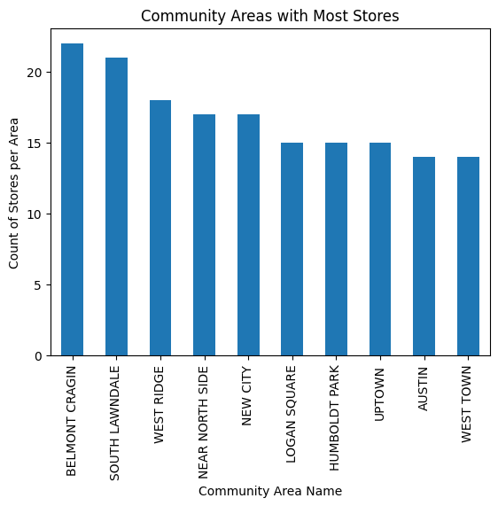

```python
#count how many times each community area name is in the dataset indicating a store
count = chicago_2013['COMMUNITY AREA NAME'].value_counts()
#with 73 areas, we cannot display all in one chart, so we will display the top 10
count1 = count[0:10]
count1.plot.bar(ylabel='Count of Stores per Area', xlabel='Community Area Name', title = "Community Areas with Most Stores")
```

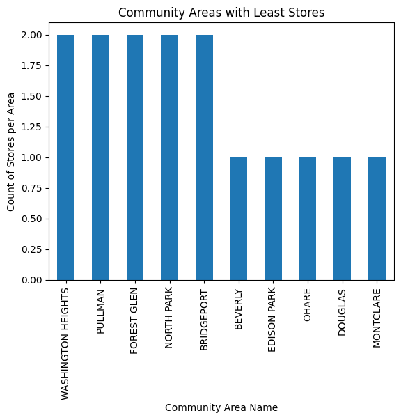

```python
#and the bottom 10 count values to see which areas were the top and bottom
count2 = count[63:73]
count2.plot.bar(ylabel='Count of Stores per Area', xlabel='Community Area Name', title = "Community Areas with Least Stores")
```

# Second Dataset and Merging

This leads us into our next dataset, which provides the per-capita income of each neighborhood in Chicago.

This dataset uses six socioeconomic indicators such as per-capita income and percent of households in the neighborhood below poverty. This data comes from the Census and uses the same “Community Area Name” variable as the grocery store dataset, which will allow us to easily merge the datasets. We can use both of these datasets in conjunction to answer another question: what is the link between grocery store accessibility and socioeconomic markers of inequality?

```python
#make the community area name column all caps so it is identical to the one in counts
chic_per_cap["COMMUNITY AREA NAME"] = chic_per_cap["COMMUNITY AREA NAME"].str.upper()
#change counted into a dataframe for manipulation purposes
counted = count.to_frame()

#change the index into a default so we can manipulate community area name
counted.reset_index(drop=False, inplace=True)

#merge per capita df and the count so we can compare census data with # stores
merged = chic_per_cap.merge(counted, on="COMMUNITY AREA NAME", how="inner")
merged = merged.sort_values(by=["count"], ascending=True)#sort by # of stores
```

```python
merged.head(10) #display the areas with the least stores and census data
```

|  | Community Area Number | COMMUNITY AREA NAME | PERCENT OF HOUSING CROWDED | PERCENT HOUSEHOLDS BELOW POVERTY | PERCENT AGED 16+ UNEMPLOYED | PERCENT AGED 25+ WITHOUT HIGH SCHOOL DIPLOMA | PERCENT AGED UNDER 18 OR OVER 64 | PER CAPITA INCOME | HARDSHIP INDEX | count |
| --- | --- | --- | --- | --- | --- | --- | --- | --- | --- | --- |
| 33 | 35.0 | DOUGLAS | 1.8 | 29.6 | 18.2 | 14.3 | 30.7 | 23791 | 47.0 | 1 |
| 66 | 72.0 | BEVERLY | 0.9 | 5.1 | 8.0 | 3.7 | 40.5 | 39523 | 12.0 | 1 |
| 8 | 9.0 | EDISON PARK | 1.1 | 3.3 | 6.5 | 7.4 | 35.3 | 40959 | 8.0 | 1 |
| 37 | 41.0 | HYDE PARK | 1.5 | 18.4 | 8.4 | 4.3 | 26.2 | 39056 | 14.0 | 2 |
| 31 | 33.0 | NEAR SOUTH SIDE | 1.3 | 13.8 | 4.9 | 7.4 | 21.8 | 59077 | 7.0 | 2 |
| 49 | 54.0 | RIVERDALE | 5.8 | 56.5 | 34.6 | 27.5 | 51.5 | 8201 | 98.0 | 2 |
| 43 | 48.0 | CALUMET HEIGHTS | 2.1 | 11.5 | 20.0 | 11.0 | 44.0 | 28887 | 38.0 | 2 |
| 45 | 50.0 | PULLMAN | 1.5 | 21.6 | 22.8 | 13.1 | 38.6 | 20588 | 51.0 | 2 |
| 55 | 60.0 | BRIDGEPORT | 4.5 | 18.9 | 13.7 | 22.2 | 31.3 | 22694 | 43.0 | 2 |
| 11 | 12.0 | FOREST GLEN | 1.1 | 7.5 | 6.8 | 4.9 | 40.5 | 44164 | 11.0 | 2 |

```python
merged.tail(10) #for visualization purposes: top 10 store count areas and census data
```

|  | Community Area Number | COMMUNITY AREA NAME | PERCENT OF HOUSING CROWDED | PERCENT HOUSEHOLDS BELOW POVERTY | PERCENT AGED 16+ UNEMPLOYED | PERCENT AGED 25+ WITHOUT HIGH SCHOOL DIPLOMA | PERCENT AGED UNDER 18 OR OVER 64 | PER CAPITA INCOME | HARDSHIP INDEX | count |
| --- | --- | --- | --- | --- | --- | --- | --- | --- | --- | --- |
| 23 | 25.0 | AUSTIN | 6.3 | 28.6 | 22.6 | 24.4 | 37.9 | 15957 | 73.0 | 14 |
| 22 | 24.0 | WEST TOWN | 2.3 | 14.7 | 6.6 | 12.9 | 21.7 | 43198 | 10.0 | 14 |
| 21 | 23.0 | HUMBOLDT PARK | 14.8 | 33.9 | 17.3 | 35.4 | 38.0 | 13781 | 85.0 | 15 |
| 20 | 22.0 | LOGAN SQUARE | 3.2 | 16.8 | 8.2 | 14.8 | 26.2 | 31908 | 23.0 | 15 |
| 2 | 3.0 | UPTOWN | 3.8 | 24.0 | 8.9 | 11.8 | 22.2 | 35787 | 20.0 | 15 |
| 56 | 61.0 | NEW CITY | 11.9 | 29.0 | 23.0 | 41.5 | 38.9 | 12765 | 91.0 | 17 |
| 7 | 8.0 | NEAR NORTH SIDE | 1.9 | 12.9 | 7.0 | 2.5 | 22.6 | 88669 | 1.0 | 17 |
| 1 | 2.0 | WEST RIDGE | 7.8 | 17.2 | 8.8 | 20.8 | 38.5 | 23040 | 46.0 | 18 |
| 28 | 30.0 | SOUTH LAWNDALE | 15.2 | 30.7 | 15.8 | 54.8 | 33.8 | 10402 | 96.0 | 21 |
| 17 | 19.0 | BELMONT CRAGIN | 10.8 | 18.7 | 14.6 | 37.3 | 37.3 | 15461 | 70.0 | 22 |

```python
print(merged.dtypes)
```

```
Community Area Number                           float64
COMMUNITY AREA NAME                              object
PERCENT OF HOUSING CROWDED                      float64
PERCENT HOUSEHOLDS BELOW POVERTY                float64
PERCENT AGED 16+ UNEMPLOYED                     float64
PERCENT AGED 25+ WITHOUT HIGH SCHOOL DIPLOMA    float64
PERCENT AGED UNDER 18 OR OVER 64                float64
PER CAPITA INCOME                                 int64
HARDSHIP INDEX                                  float64
count                                             int64
dtype: object
```

# Scatterplots

Below are two visualizations of the combined datasets. The combined set allows us to look at multiple variable combinations, below are two that made the most sense for our initial investigation.

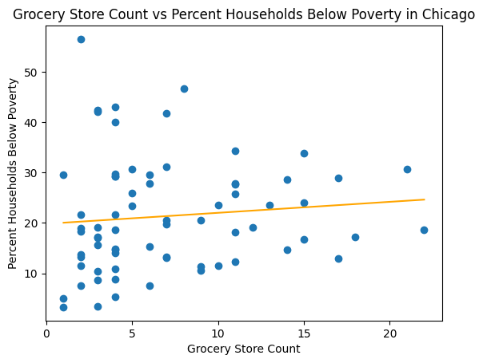

```python
#create x and y
x = merged["count"]
y = merged["PERCENT HOUSEHOLDS BELOW POVERTY"]
plt.scatter(x, y)
#create a line based on x and y, fed into m(slope) and b(yint)
m, b = np.polyfit(x, y, 1)
plt.plot(x, m*x + b, color='orange')#this is the slope formula y=mx+b to make the line
#add some labels
plt.xlabel("Grocery Store Count")
plt.ylabel("Percent Households Below Poverty")
plt.title("Grocery Store Count vs Percent Households Below Poverty in Chicago")
plt.show()
```

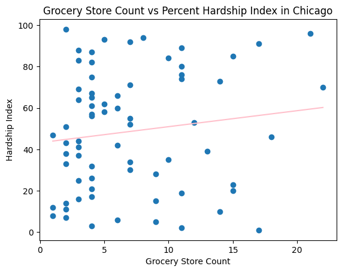

```python
#same as above, for a different y value
x = merged["count"]
y = merged["HARDSHIP INDEX"]
plt.scatter(x, y)

m, b = np.polyfit(x, y, 1)  # m is the slope, b is the intercept
plt.plot(x, m*x + b, color='pink')#this is the slope formula y=mx+b to make the line

plt.xlabel("Grocery Store Count")
plt.ylabel("Hardship Index")
plt.title("Grocery Store Count vs Percent Hardship Index in Chicago")
plt.show()
```

# Initial Findings & Future Work

From our initial visualizations, the connection is vague. We visualized how the number of grocery stores per community area related to the hardship index and percentage of households below poverty, respectively, and both had slight positive correlations which would indicate that an increase in stores meant an increase in poverty indicators. This was not what we were expecting, but two things could improve the certainty of this result.

For one, as above, creating a more recent and more full dataset of stores would help greatly. At present, most of the communities have less than 6 stores in them, with a few skewing towards having more than 15. More data on grocery stores in these areas would create more validity to our findings. Secondly, if we are able to classify the price range of each grocery store, this would also help us understand these results on a deeper level. Even if an area has a large amount of stores, they could be dollar stores or stores comparable to Walgreens. Knowing the price range of the stores included in the survey would also allow us to better understand the data and results.

```python
from google.colab import drive
drive.mount('/content/drive')
```

```python
%%shell
#!jupyter nbconvert --to html /content/drive/CMPS3160RheganKaylaMS1.ipynb
jupyter nbconvert CMPS3160RheganKaylaMS1.ipynb --to html
#run this, makes a copy of the notebook as html, put that into index on github
```

[output not shown]

[output cut: 133 more lines]

[output not shown]

[output not shown]